# Cretu Dumitru, IS-211M, laboratory work nr. 1

```
Train Score: 0.04 RMSE
Test Score: 0.07 RMSE
```

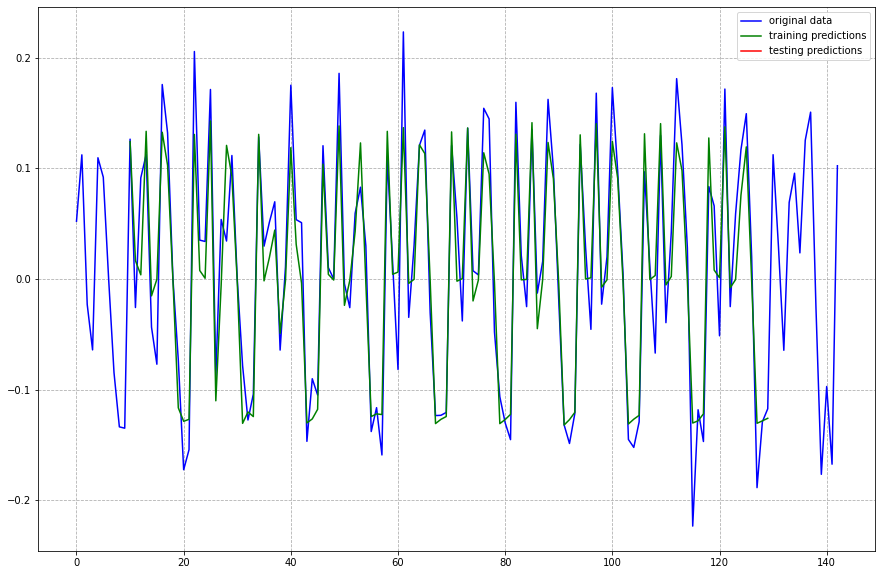

```python
# calculate root mean squared error
trainScore = math.sqrt(mean_squared_error(trainY, train_predict_pure[:, 0]))
print('Train Score: %.2f RMSE' % (trainScore))
testScore = math.sqrt(mean_squared_error(testY, test_predict_pure[:, 0]))
print('Test Score: %.2f RMSE' % (testScore))

train_predict_df = pd.DataFrame(train_predict_pure[:,0])
test_predict_df = pd.DataFrame(test_predict_pure[:,0])
predict_df = pd.concat([train_predict_df, test_predict_df])
predict_df.reset_index(inplace=True)
predict_df.drop(columns=["index"], inplace=True)

# plot baseline and predictions
plt.figure(figsize=(15, 10))
plt.plot(log_diff_data, color='b', label="original data")
plt.plot(predict_df[:len(train_predict_df)].index + 10, predict_df[:len(train_predict_df)][0], color="g",
         label='training predictions')
plt.plot(predict_df[len(train_predict_df):].index,
         predict_df[len(train_predict_df):][0], color="r", label="testing predictions")
plt.legend()
plt.grid(True, linestyle='--')
plt.show()
```

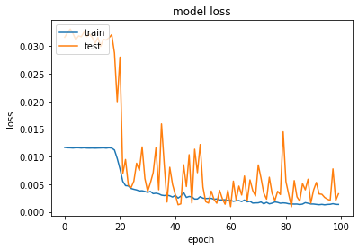

```python
plt.plot(history.history['accuracy'])
plt.plot(history.history['val_accuracy'])
plt.title('model accuracy')
plt.ylabel('accuracy')
plt.xlabel('epoch')
plt.legend(['train', 'test'], loc='upper left')
plt.show()

plt.plot(history.history['loss'])
plt.plot(history.history['val_loss'])
plt.title('model loss')
plt.ylabel('loss')
plt.xlabel('epoch')
plt.legend(['train', 'test'], loc='upper left')
plt.show()
```

[output not shown]

```
Train Score: 127.77 RMSE
```

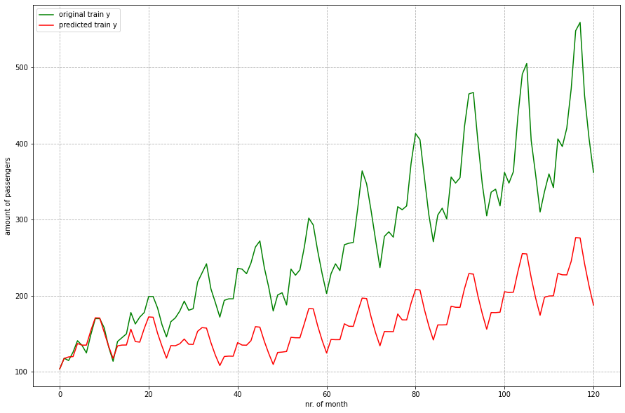

```python
data = dataset.values
data = data.astype('float32')
log_data = np.log(data)

first_train_y = log_data[look_back]
# first_test_value = log_data[train_size]

train_predictions = train_predict_pure[:,0]
train_predictions = np.insert(train_predictions, 0, first_train_y)
train_predictions = np.exp(train_predictions.cumsum())

original_train_Y = trainY
original_train_Y = np.insert(original_train_Y, 0, first_train_y)
original_train_Y = np.exp(original_train_Y.cumsum())

trainScore = math.sqrt(mean_squared_error(original_train_Y, train_predictions))
print('Train Score: %.2f RMSE' % (trainScore))

plt.figure(figsize=(15, 10))
plt.plot(original_train_Y, color='g', label='original train y')
plt.plot(train_predictions, color='r', label='predicted train y')
plt.legend()
plt.xlabel("nr. of month")
plt.ylabel("amount of passengers")
plt.grid(True, linestyle='--')
plt.show()
```

Bad match between original data and predictions, overfit, desired number of epoches is 20

# LSTM four layers, 50 neurons, 100 epoches, log with differential applied

```python
data = dataset.values
data = data.astype('float32')
log_data = np.log(data)

log_diff_data = np.diff(log_data, axis=0)

train_size = int(len(log_diff_data) * 0.9167)
test_size = len(log_diff_data) - train_size
train, test = log_diff_data[0:train_size,:], log_diff_data[train_size:len(log_diff_data),:]
print(len(train), len(test))

look_back = 10
trainX, trainY = create_dataset(train, look_back)
testX, testY = create_dataset(test, look_back)

trainX = np.reshape(trainX, (trainX.shape[0], 1, trainX.shape[1]))
testX = np.reshape(testX, (testX.shape[0], 1, testX.shape[1]))

model = Sequential()
# model.add(LSTM(4, input_shape=(1, look_back)))
model.add(LSTM(4, batch_input_shape=(1, 1, look_back), stateful=True, return_sequences=True))
model.add(Dense(50))
model.add(LSTM(4, batch_input_shape=(1, 1, look_back), stateful=True, return_sequences=True))
model.add(Dense(50))
model.add(LSTM(4, batch_input_shape=(1, 1, look_back), stateful=True, return_sequences=True))
model.add(Dense(50))
model.add(LSTM(4, batch_input_shape=(1, 1, look_back), stateful=True))
model.add(Dense(50))
model.compile(loss='mean_squared_error', optimizer='adam', metrics=['accuracy'])
history = model.fit(trainX, trainY, epochs=100, validation_data=(testX, testY), batch_size=1, verbose=2)

# make predictions
train_predict_pure = model.predict(trainX, batch_size=1)
test_predict_pure = model.predict(testX, batch_size=1)
```

```
131 12
120/120 - 9s - loss: 0.0117 - accuracy: 0.0000e+00 - val_loss: 0.0317 - val_accuracy: 0.0000e+00 - 9s/epoch - 73ms/step
120/120 - 1s - loss: 0.0116 - accuracy: 0.0000e+00 - val_loss: 0.0325 - val_accuracy: 0.0000e+00 - 544ms/epoch - 5ms/step
120/120 - 1s - loss: 0.0116 - accuracy: 0.0000e+00 - val_loss: 0.0332 - val_accuracy: 0.0000e+00 - 537ms/epoch - 4ms/step
120/120 - 1s - loss: 0.0116 - accuracy: 0.0000e+00 - val_loss: 0.0321 - val_accuracy: 0.0000e+00 - 534ms/epoch - 4ms/step
120/120 - 1s - loss: 0.0116 - accuracy: 0.0000e+00 - val_loss: 0.0311 - val_accuracy: 0.0000e+00 - 537ms/epoch - 4ms/step
120/120 - 1s - loss: 0.0116 - accuracy: 0.0000e+00 - val_loss: 0.0319 - val_accuracy: 0.0000e+00 - 535ms/epoch - 4ms/step
120/120 - 1s - loss: 0.0116 - accuracy: 0.0000e+00 - val_loss: 0.0317 - val_accuracy: 0.0000e+00 - 543ms/epoch - 5ms/step
120/120 - 1s - loss: 0.0116 - accuracy: 0.0000e+00 - val_loss: 0.0326 - val_accuracy: 0.0000e+00 - 516ms/epoch - 4ms/step
120/120 - 1s - loss: 0.0116 - accuracy: 0.0000e+00 - val_loss: 0.0317 - val_accuracy: 0.0000e+00 - 564ms/epoch - 5ms/step
120/120 - 1s - loss: 0.0115 - accuracy: 0.0000e+00 - val_loss: 0.0322 - val_accuracy: 0.0000e+00 - 528ms/epoch - 4ms/step
120/120 - 1s - loss: 0.0116 - accuracy: 0.0000e+00 - val_loss: 0.0315 - val_accuracy: 0.0000e+00 - 515ms/epoch - 4ms/step
120/120 - 1s - loss: 0.0115 - accuracy: 0.0000e+00 - val_loss: 0.0305 - val_accuracy: 0.0000e+00 - 501ms/epoch - 4ms/step
120/120 - 1s - loss: 0.0116 - accuracy: 0.0000e+00 - val_loss: 0.0316 - val_accuracy: 0.0000e+00 - 539ms/epoch - 4ms/step
120/120 - 1s - loss: 0.0116 - accuracy: 0.0000e+00 - val_loss: 0.0299 - val_accuracy: 0.0000e+00 - 532ms/epoch - 4ms/step
120/120 - 1s - loss: 0.0116 - accuracy: 0.0000e+00 - val_loss: 0.0313 - val_accuracy: 0.0000e+00 - 536ms/epoch - 4ms/step
120/120 - 1s - loss: 0.0115 - accuracy: 0.0000e+00 - val_loss: 0.0311 - val_accuracy: 0.0000e+00 - 506ms/epoch - 4ms/step
120/120 - 1s - loss: 0.0116 - accuracy: 0.0000e+00 - val_loss: 0.0314 - val_accuracy: 0.0000e+00 - 522ms/epoch - 4ms/step
120/120 - 1s - loss: 0.0116 - accuracy: 0.0000e+00 - val_loss: 0.0313 - val_accuracy: 0.0000e+00 - 547ms/epoch - 5ms/step
120/120 - 1s - loss: 0.0116 - accuracy: 0.0000e+00 - val_loss: 0.0313 - val_accuracy: 0.0000e+00 - 537ms/epoch - 4ms/step
120/120 - 1s - loss: 0.0115 - accuracy: 0.0000e+00 - val_loss: 0.0316 - val_accuracy: 0.0000e+00 - 556ms/epoch - 5ms/step
120/120 - 1s - loss: 0.0116 - accuracy: 0.0000e+00 - val_loss: 0.0325 - val_accuracy: 0.0000e+00 - 548ms/epoch - 5ms/step
120/120 - 0s - loss: 0.0115 - accuracy: 0.0000e+00 - val_loss: 0.0328 - val_accuracy: 0.0000e+00 - 496ms/epoch - 4ms/step
120/120 - 1s - loss: 0.0115 - accuracy: 0.0000e+00 - val_loss: 0.0316 - val_accuracy: 0.0000e+00 - 511ms/epoch - 4ms/step
120/120 - 0s - loss: 0.0116 - accuracy: 0.0000e+00 - val_loss: 0.0306 - val_accuracy: 0.0000e+00 - 485ms/epoch - 4ms/step
120/120 - 1s - loss: 0.0116 - accuracy: 0.0000e+00 - val_loss: 0.0311 - val_accuracy: 0.0000e+00 - 514ms/epoch - 4ms/step
120/120 - 0s - loss: 0.0116 - accuracy: 0.0000e+00 - val_loss: 0.0320 - val_accuracy: 0.0000e+00 - 494ms/epoch - 4ms/step
120/120 - 0s - loss: 0.0116 - accuracy: 0.0000e+00 - val_loss: 0.0318 - val_accuracy: 0.0000e+00 - 494ms/epoch - 4ms/step
120/120 - 1s - loss: 0.0116 - accuracy: 0.0000e+00 - val_loss: 0.0311 - val_accuracy: 0.0000e+00 - 510ms/epoch - 4ms/step
120/120 - 1s - loss: 0.0115 - accuracy: 0.0000e+00 - val_loss: 0.0311 - val_accuracy: 0.0000e+00 - 503ms/epoch - 4ms/step
120/120 - 0s - loss: 0.0115 - accuracy: 0.0000e+00 - val_loss: 0.0309 - val_accuracy: 0.0000e+00 - 495ms/epoch - 4ms/step
120/120 - 1s - loss: 0.0116 - accuracy: 0.0000e+00 - val_loss: 0.0313 - val_accuracy: 0.0000e+00 - 533ms/epoch - 4ms/step
120/120 - 0s - loss: 0.0116 - accuracy: 0.0000e+00 - val_loss: 0.0319 - val_accuracy: 0.0000e+00 - 500ms/epoch - 4ms/step
120/120 - 1s - loss: 0.0116 - accuracy: 0.0000e+00 - val_loss: 0.0314 - val_accuracy: 0.0000e+00 - 501ms/epoch - 4ms/step
120/120 - 1s - loss: 0.0116 - accuracy: 0.0000e+00 - val_loss: 0.0316 - val_accuracy: 0.0000e+00 - 501ms/epoch - 4ms/step
120/120 - 0s - loss: 0.0115 - accuracy: 0.0000e+00 - val_loss: 0.0323 - val_accuracy: 0.0000e+00 - 488ms/epoch - 4ms/step
120/120 - 1s - loss: 0.0116 - accuracy: 0.0000e+00 - val_loss: 0.0326 - val_accuracy: 0.0000e+00 - 509ms/epoch - 4ms/step
120/120 - 1s - loss: 0.0116 - accuracy: 0.0000e+00 - val_loss: 0.0316 - val_accuracy: 0.0000e+00 - 524ms/epoch - 4ms/step
120/120 - 1s - loss: 0.0116 - accuracy: 0.0000e+00 - val_loss: 0.0290 - val_accuracy: 0.0000e+00 - 574ms/epoch - 5ms/step
120/120 - 1s - loss: 0.0116 - accuracy: 0.0000e+00 - val_loss: 0.0317 - val_accuracy: 0.0000e+00 - 515ms/epoch - 4ms/step
```

[output cut: 46 more lines]

```
120/120 - 1s - loss: 0.0116 - accuracy: 0.0000e+00 - val_loss: 0.0319 - val_accuracy: 0.0000e+00 - 524ms/epoch - 4ms/step
120/120 - 1s - loss: 0.0115 - accuracy: 0.0000e+00 - val_loss: 0.0314 - val_accuracy: 0.0000e+00 - 509ms/epoch - 4ms/step
120/120 - 0s - loss: 0.0115 - accuracy: 0.0000e+00 - val_loss: 0.0318 - val_accuracy: 0.0000e+00 - 496ms/epoch - 4ms/step
120/120 - 1s - loss: 0.0116 - accuracy: 0.0000e+00 - val_loss: 0.0316 - val_accuracy: 0.0000e+00 - 515ms/epoch - 4ms/step
120/120 - 1s - loss: 0.0116 - accuracy: 0.0000e+00 - val_loss: 0.0318 - val_accuracy: 0.0000e+00 - 515ms/epoch - 4ms/step
120/120 - 0s - loss: 0.0116 - accuracy: 0.0000e+00 - val_loss: 0.0307 - val_accuracy: 0.0000e+00 - 482ms/epoch - 4ms/step
120/120 - 1s - loss: 0.0116 - accuracy: 0.0000e+00 - val_loss: 0.0308 - val_accuracy: 0.0000e+00 - 505ms/epoch - 4ms/step
120/120 - 1s - loss: 0.0116 - accuracy: 0.0000e+00 - val_loss: 0.0294 - val_accuracy: 0.0000e+00 - 505ms/epoch - 4ms/step
120/120 - 1s - loss: 0.0116 - accuracy: 0.0000e+00 - val_loss: 0.0309 - val_accuracy: 0.0000e+00 - 520ms/epoch - 4ms/step
120/120 - 1s - loss: 0.0116 - accuracy: 0.0000e+00 - val_loss: 0.0313 - val_accuracy: 0.0000e+00 - 505ms/epoch - 4ms/step
120/120 - 1s - loss: 0.0116 - accuracy: 0.0000e+00 - val_loss: 0.0322 - val_accuracy: 0.0000e+00 - 525ms/epoch - 4ms/step
120/120 - 1s - loss: 0.0116 - accuracy: 0.0000e+00 - val_loss: 0.0311 - val_accuracy: 0.0000e+00 - 518ms/epoch - 4ms/step
120/120 - 1s - loss: 0.0115 - accuracy: 0.0000e+00 - val_loss: 0.0321 - val_accuracy: 0.0000e+00 - 513ms/epoch - 4ms/step
120/120 - 0s - loss: 0.0116 - accuracy: 0.0000e+00 - val_loss: 0.0312 - val_accuracy: 0.0000e+00 - 499ms/epoch - 4ms/step
120/120 - 1s - loss: 0.0116 - accuracy: 0.0000e+00 - val_loss: 0.0315 - val_accuracy: 0.0000e+00 - 536ms/epoch - 4ms/step
```

```
Train Score: 0.11 RMSE
Test Score: 0.18 RMSE
```

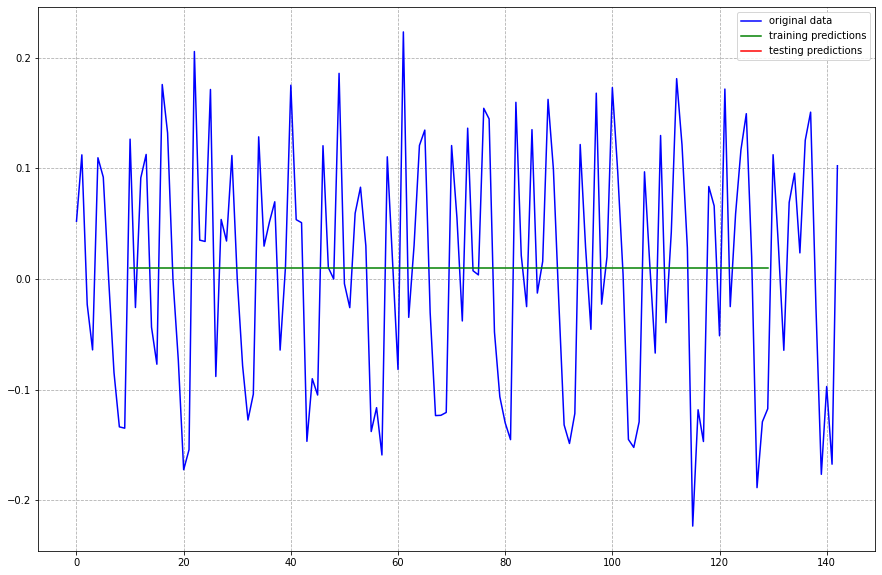

```python
# calculate root mean squared error
trainScore = math.sqrt(mean_squared_error(trainY, train_predict_pure[:, 0]))
print('Train Score: %.2f RMSE' % (trainScore))
testScore = math.sqrt(mean_squared_error(testY, test_predict_pure[:, 0]))
print('Test Score: %.2f RMSE' % (testScore))

train_predict_df = pd.DataFrame(train_predict_pure[:,0])
test_predict_df = pd.DataFrame(test_predict_pure[:,0])
predict_df = pd.concat([train_predict_df, test_predict_df])
predict_df.reset_index(inplace=True)
predict_df.drop(columns=["index"], inplace=True)

# plot baseline and predictions
plt.figure(figsize=(15, 10))
plt.plot(log_diff_data, color='b', label="original data")
plt.plot(predict_df[:len(train_predict_df)].index + 10, predict_df[:len(train_predict_df)][0], color="g",
         label='training predictions')
plt.plot(predict_df[len(train_predict_df):].index,
         predict_df[len(train_predict_df):][0], color="r", label="testing predictions")
plt.legend()
plt.grid(True, linestyle='--')
plt.show()
```

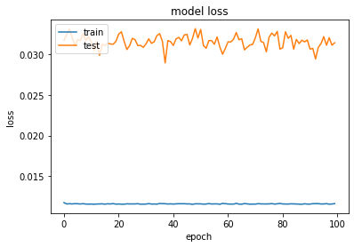

```python
plt.plot(history.history['accuracy'])
plt.plot(history.history['val_accuracy'])
plt.title('model accuracy')
plt.ylabel('accuracy')
plt.xlabel('epoch')
plt.legend(['train', 'test'], loc='upper left')
plt.show()

plt.plot(history.history['loss'])
plt.plot(history.history['val_loss'])
plt.title('model loss')
plt.ylabel('loss')
plt.xlabel('epoch')
plt.legend(['train', 'test'], loc='upper left')
plt.show()
```

[output not shown]

```
Train Score: 85.00 RMSE
```

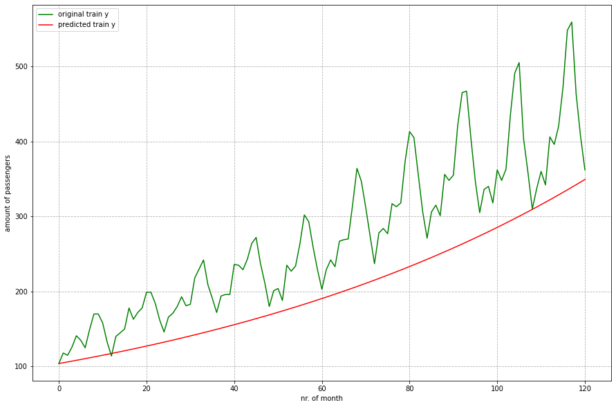

```python
data = dataset.values
data = data.astype('float32')
log_data = np.log(data)

first_train_y = log_data[look_back]
# first_test_value = log_data[train_size]

train_predictions = train_predict_pure[:,0]
train_predictions = np.insert(train_predictions, 0, first_train_y)
train_predictions = np.exp(train_predictions.cumsum())

original_train_Y = trainY
original_train_Y = np.insert(original_train_Y, 0, first_train_y)
original_train_Y = np.exp(original_train_Y.cumsum())

trainScore = math.sqrt(mean_squared_error(original_train_Y, train_predictions))
print('Train Score: %.2f RMSE' % (trainScore))

plt.figure(figsize=(15, 10))
plt.plot(original_train_Y, color='g', label='original train y')
plt.plot(train_predictions, color='r', label='predicted train y')
plt.legend()
plt.xlabel("nr. of month")
plt.ylabel("amount of passengers")
plt.grid(True, linestyle='--')
plt.show()
```

# LSTM four layers, 100 neurons, 100 epoches, log with differential applied

```python
data = dataset.values
data = data.astype('float32')
log_data = np.log(data)

log_diff_data = np.diff(log_data, axis=0)

train_size = int(len(log_diff_data) * 0.9167)
test_size = len(log_diff_data) - train_size
train, test = log_diff_data[0:train_size,:], log_diff_data[train_size:len(log_diff_data),:]
print(len(train), len(test))

look_back = 10
trainX, trainY = create_dataset(train, look_back)
testX, testY = create_dataset(test, look_back)

trainX = np.reshape(trainX, (trainX.shape[0], 1, trainX.shape[1]))
testX = np.reshape(testX, (testX.shape[0], 1, testX.shape[1]))

model = Sequential()
# model.add(LSTM(4, input_shape=(1, look_back)))
model.add(LSTM(4, batch_input_shape=(1, 1, look_back), stateful=True, return_sequences=True))
model.add(Dense(100))
model.add(LSTM(4, batch_input_shape=(1, 1, look_back), stateful=True, return_sequences=True))
model.add(Dense(100))
model.add(LSTM(4, batch_input_shape=(1, 1, look_back), stateful=True, return_sequences=True))
model.add(Dense(100))
model.add(LSTM(4, batch_input_shape=(1, 1, look_back), stateful=True))
model.add(Dense(100))
model.compile(loss='mean_squared_error', optimizer='adam', metrics=['accuracy'])
history = model.fit(trainX, trainY, epochs=100, validation_data=(testX, testY), batch_size=1, verbose=2)

# make predictions
train_predict_pure = model.predict(trainX, batch_size=1)
test_predict_pure = model.predict(testX, batch_size=1)
```

```
131 12
120/120 - 9s - loss: 0.0117 - accuracy: 0.0000e+00 - val_loss: 0.0321 - val_accuracy: 0.0000e+00 - 9s/epoch - 72ms/step
120/120 - 1s - loss: 0.0116 - accuracy: 0.0083 - val_loss: 0.0321 - val_accuracy: 0.0000e+00 - 543ms/epoch - 5ms/step
120/120 - 1s - loss: 0.0116 - accuracy: 0.0000e+00 - val_loss: 0.0331 - val_accuracy: 0.0000e+00 - 583ms/epoch - 5ms/step
120/120 - 1s - loss: 0.0116 - accuracy: 0.0000e+00 - val_loss: 0.0320 - val_accuracy: 0.0000e+00 - 562ms/epoch - 5ms/step
120/120 - 1s - loss: 0.0116 - accuracy: 0.0000e+00 - val_loss: 0.0312 - val_accuracy: 0.0000e+00 - 573ms/epoch - 5ms/step
120/120 - 1s - loss: 0.0116 - accuracy: 0.0000e+00 - val_loss: 0.0318 - val_accuracy: 0.0000e+00 - 568ms/epoch - 5ms/step
120/120 - 1s - loss: 0.0116 - accuracy: 0.0000e+00 - val_loss: 0.0317 - val_accuracy: 0.0000e+00 - 537ms/epoch - 4ms/step
120/120 - 1s - loss: 0.0116 - accuracy: 0.0000e+00 - val_loss: 0.0325 - val_accuracy: 0.0000e+00 - 529ms/epoch - 4ms/step
120/120 - 1s - loss: 0.0116 - accuracy: 0.0000e+00 - val_loss: 0.0317 - val_accuracy: 0.0000e+00 - 539ms/epoch - 4ms/step
120/120 - 1s - loss: 0.0115 - accuracy: 0.0083 - val_loss: 0.0322 - val_accuracy: 0.0000e+00 - 517ms/epoch - 4ms/step
120/120 - 1s - loss: 0.0116 - accuracy: 0.0000e+00 - val_loss: 0.0316 - val_accuracy: 0.0000e+00 - 556ms/epoch - 5ms/step
120/120 - 1s - loss: 0.0115 - accuracy: 0.0000e+00 - val_loss: 0.0305 - val_accuracy: 0.0000e+00 - 525ms/epoch - 4ms/step
120/120 - 1s - loss: 0.0116 - accuracy: 0.0000e+00 - val_loss: 0.0316 - val_accuracy: 0.0000e+00 - 536ms/epoch - 4ms/step
120/120 - 1s - loss: 0.0116 - accuracy: 0.0000e+00 - val_loss: 0.0298 - val_accuracy: 0.0000e+00 - 540ms/epoch - 5ms/step
120/120 - 1s - loss: 0.0116 - accuracy: 0.0000e+00 - val_loss: 0.0313 - val_accuracy: 0.0000e+00 - 554ms/epoch - 5ms/step
120/120 - 1s - loss: 0.0115 - accuracy: 0.0000e+00 - val_loss: 0.0311 - val_accuracy: 0.0000e+00 - 540ms/epoch - 4ms/step
120/120 - 1s - loss: 0.0116 - accuracy: 0.0000e+00 - val_loss: 0.0314 - val_accuracy: 0.0000e+00 - 553ms/epoch - 5ms/step
120/120 - 1s - loss: 0.0116 - accuracy: 0.0000e+00 - val_loss: 0.0313 - val_accuracy: 0.0000e+00 - 540ms/epoch - 4ms/step
120/120 - 1s - loss: 0.0116 - accuracy: 0.0000e+00 - val_loss: 0.0313 - val_accuracy: 0.0000e+00 - 550ms/epoch - 5ms/step
120/120 - 1s - loss: 0.0115 - accuracy: 0.0000e+00 - val_loss: 0.0316 - val_accuracy: 0.0000e+00 - 565ms/epoch - 5ms/step
120/120 - 1s - loss: 0.0116 - accuracy: 0.0000e+00 - val_loss: 0.0325 - val_accuracy: 0.0000e+00 - 542ms/epoch - 5ms/step
120/120 - 1s - loss: 0.0115 - accuracy: 0.0000e+00 - val_loss: 0.0328 - val_accuracy: 0.0000e+00 - 550ms/epoch - 5ms/step
120/120 - 1s - loss: 0.0115 - accuracy: 0.0000e+00 - val_loss: 0.0316 - val_accuracy: 0.0000e+00 - 524ms/epoch - 4ms/step
120/120 - 1s - loss: 0.0116 - accuracy: 0.0000e+00 - val_loss: 0.0306 - val_accuracy: 0.0000e+00 - 573ms/epoch - 5ms/step
120/120 - 1s - loss: 0.0116 - accuracy: 0.0000e+00 - val_loss: 0.0311 - val_accuracy: 0.0000e+00 - 569ms/epoch - 5ms/step
120/120 - 1s - loss: 0.0116 - accuracy: 0.0000e+00 - val_loss: 0.0320 - val_accuracy: 0.0000e+00 - 541ms/epoch - 5ms/step
120/120 - 1s - loss: 0.0116 - accuracy: 0.0000e+00 - val_loss: 0.0318 - val_accuracy: 0.0000e+00 - 542ms/epoch - 5ms/step
120/120 - 1s - loss: 0.0116 - accuracy: 0.0083 - val_loss: 0.0311 - val_accuracy: 0.0000e+00 - 541ms/epoch - 5ms/step
120/120 - 1s - loss: 0.0115 - accuracy: 0.0000e+00 - val_loss: 0.0311 - val_accuracy: 0.0000e+00 - 532ms/epoch - 4ms/step
120/120 - 1s - loss: 0.0115 - accuracy: 0.0000e+00 - val_loss: 0.0309 - val_accuracy: 0.0000e+00 - 529ms/epoch - 4ms/step
120/120 - 1s - loss: 0.0116 - accuracy: 0.0000e+00 - val_loss: 0.0313 - val_accuracy: 0.0000e+00 - 569ms/epoch - 5ms/step
120/120 - 1s - loss: 0.0116 - accuracy: 0.0000e+00 - val_loss: 0.0319 - val_accuracy: 0.0000e+00 - 531ms/epoch - 4ms/step
120/120 - 1s - loss: 0.0116 - accuracy: 0.0000e+00 - val_loss: 0.0314 - val_accuracy: 0.0000e+00 - 581ms/epoch - 5ms/step
120/120 - 1s - loss: 0.0116 - accuracy: 0.0000e+00 - val_loss: 0.0316 - val_accuracy: 0.0000e+00 - 550ms/epoch - 5ms/step
120/120 - 1s - loss: 0.0115 - accuracy: 0.0000e+00 - val_loss: 0.0323 - val_accuracy: 0.0000e+00 - 546ms/epoch - 5ms/step
120/120 - 1s - loss: 0.0116 - accuracy: 0.0000e+00 - val_loss: 0.0326 - val_accuracy: 0.0000e+00 - 545ms/epoch - 5ms/step
120/120 - 1s - loss: 0.0116 - accuracy: 0.0000e+00 - val_loss: 0.0313 - val_accuracy: 0.0000e+00 - 545ms/epoch - 5ms/step
120/120 - 1s - loss: 0.0116 - accuracy: 0.0000e+00 - val_loss: 0.0307 - val_accuracy: 0.0000e+00 - 555ms/epoch - 5ms/step
120/120 - 1s - loss: 0.0115 - accuracy: 0.0000e+00 - val_loss: 0.0316 - val_accuracy: 0.0000e+00 - 533ms/epoch - 4ms/step
```

[output cut: 46 more lines]

```
120/120 - 1s - loss: 0.0116 - accuracy: 0.0000e+00 - val_loss: 0.0319 - val_accuracy: 0.0000e+00 - 536ms/epoch - 4ms/step
120/120 - 1s - loss: 0.0115 - accuracy: 0.0000e+00 - val_loss: 0.0314 - val_accuracy: 0.0000e+00 - 505ms/epoch - 4ms/step
120/120 - 1s - loss: 0.0115 - accuracy: 0.0000e+00 - val_loss: 0.0318 - val_accuracy: 0.0000e+00 - 551ms/epoch - 5ms/step
120/120 - 1s - loss: 0.0116 - accuracy: 0.0000e+00 - val_loss: 0.0316 - val_accuracy: 0.0000e+00 - 556ms/epoch - 5ms/step
120/120 - 1s - loss: 0.0116 - accuracy: 0.0000e+00 - val_loss: 0.0318 - val_accuracy: 0.0000e+00 - 534ms/epoch - 4ms/step
120/120 - 1s - loss: 0.0116 - accuracy: 0.0000e+00 - val_loss: 0.0307 - val_accuracy: 0.0000e+00 - 530ms/epoch - 4ms/step
120/120 - 1s - loss: 0.0116 - accuracy: 0.0000e+00 - val_loss: 0.0308 - val_accuracy: 0.0000e+00 - 529ms/epoch - 4ms/step
120/120 - 1s - loss: 0.0116 - accuracy: 0.0000e+00 - val_loss: 0.0294 - val_accuracy: 0.0000e+00 - 507ms/epoch - 4ms/step
120/120 - 1s - loss: 0.0116 - accuracy: 0.0000e+00 - val_loss: 0.0309 - val_accuracy: 0.0000e+00 - 528ms/epoch - 4ms/step
120/120 - 1s - loss: 0.0116 - accuracy: 0.0000e+00 - val_loss: 0.0313 - val_accuracy: 0.0000e+00 - 556ms/epoch - 5ms/step
120/120 - 1s - loss: 0.0116 - accuracy: 0.0000e+00 - val_loss: 0.0322 - val_accuracy: 0.0000e+00 - 527ms/epoch - 4ms/step
120/120 - 1s - loss: 0.0116 - accuracy: 0.0000e+00 - val_loss: 0.0311 - val_accuracy: 0.0000e+00 - 564ms/epoch - 5ms/step
120/120 - 1s - loss: 0.0115 - accuracy: 0.0000e+00 - val_loss: 0.0321 - val_accuracy: 0.0000e+00 - 524ms/epoch - 4ms/step
120/120 - 1s - loss: 0.0116 - accuracy: 0.0000e+00 - val_loss: 0.0312 - val_accuracy: 0.0000e+00 - 543ms/epoch - 5ms/step
120/120 - 1s - loss: 0.0116 - accuracy: 0.0000e+00 - val_loss: 0.0315 - val_accuracy: 0.0000e+00 - 524ms/epoch - 4ms/step
```

```
Train Score: 0.11 RMSE
Test Score: 0.18 RMSE
```

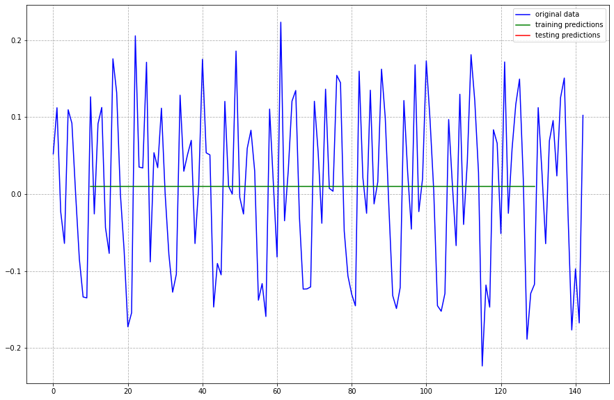

```python
# calculate root mean squared error
trainScore = math.sqrt(mean_squared_error(trainY, train_predict_pure[:, 0]))
print('Train Score: %.2f RMSE' % (trainScore))
testScore = math.sqrt(mean_squared_error(testY, test_predict_pure[:, 0]))
print('Test Score: %.2f RMSE' % (testScore))

train_predict_df = pd.DataFrame(train_predict_pure[:,0])
test_predict_df = pd.DataFrame(test_predict_pure[:,0])
predict_df = pd.concat([train_predict_df, test_predict_df])
predict_df.reset_index(inplace=True)
predict_df.drop(columns=["index"], inplace=True)

# plot baseline and predictions
plt.figure(figsize=(15, 10))
plt.plot(log_diff_data, color='b', label="original data")
plt.plot(predict_df[:len(train_predict_df)].index + 10, predict_df[:len(train_predict_df)][0], color="g",
         label='training predictions')
plt.plot(predict_df[len(train_predict_df):].index,
         predict_df[len(train_predict_df):][0], color="r", label="testing predictions")
plt.legend()
plt.grid(True, linestyle='--')
plt.show()
```

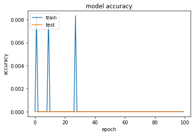

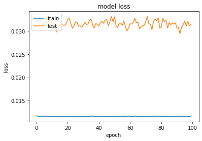

```python
plt.plot(history.history['accuracy'])
plt.plot(history.history['val_accuracy'])
plt.title('model accuracy')
plt.ylabel('accuracy')
plt.xlabel('epoch')
plt.legend(['train', 'test'], loc='upper left')
plt.show()

plt.plot(history.history['loss'])
plt.plot(history.history['val_loss'])
plt.title('model loss')
plt.ylabel('loss')
plt.xlabel('epoch')
plt.legend(['train', 'test'], loc='upper left')
plt.show()
```

```
Train Score: 85.04 RMSE
```

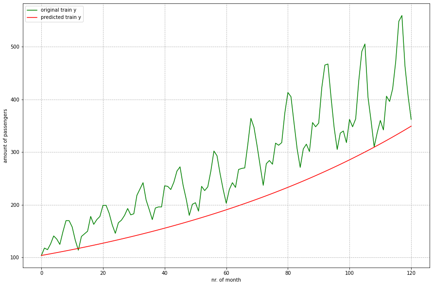

```python
data = dataset.values
data = data.astype('float32')
log_data = np.log(data)

first_train_y = log_data[look_back]

train_predictions = train_predict_pure[:,0]
train_predictions = np.insert(train_predictions, 0, first_train_y)
train_predictions = np.exp(train_predictions.cumsum())

original_train_Y = trainY
original_train_Y = np.insert(original_train_Y, 0, first_train_y)
original_train_Y = np.exp(original_train_Y.cumsum())

trainScore = math.sqrt(mean_squared_error(original_train_Y, train_predictions))
print('Train Score: %.2f RMSE' % (trainScore))

plt.figure(figsize=(15, 10))
plt.plot(original_train_Y, color='g', label='original train y')
plt.plot(train_predictions, color='r', label='predicted train y')
plt.legend()
plt.xlabel("nr. of month")
plt.ylabel("amount of passengers")
plt.grid(True, linestyle='--')
plt.show()
```

The same case as previous model, terrible match with original values

# Conclusions

Out of all presented models the best matches are in 3 cases:

1. LSTM over the original data with MinMax scaling and concept of "use current month to predict next one";
2. LSTM over the data transformed conform laboratory work requirements and with 500 epoches, 25 neurons and one layer;
3. LSTM over the data transformed conform laboratory work requirements and with 2 layers, 50 neurons per layer, 100 epoches.

The last case will be the most universal one, because it is created with elimination of the cyclic and trending aspects of the original dataset, but closer to the end values start to deviate, meaning that this model should be improved to achieve better results and make sure that it can be used in the future.

The second case also gives great result, which starts to differ more and more going further through time. It also will require more improvements to be usable with more records.

The first model looks very promising. It is primitive, but efficient concept that led to great results and the best RMSE results.